# Testing "Incremental" - the kick ass pipeline for optimising Stacks parameters!

## How to use this notebook

If you are unfamiliar with jupyter notebooks - they will change your life :)

All code cells are executable. And they can be code cells or markdown cells (like this one).

The "cell magic" below means that all plots will be plotted inline in the notebook (default is to open a new window for each plot, which is annoying).

Hopefully I have explained everything well as I go through, but if not just ask. In theory, for the analyses all you need to do, is change the paths to the data and you should be able to recreate the results that I got here.

I am using Stacks v 1.35, the pipeline worked on v 1.30 but I think there is now a version 1.44, so perhaps best to start testing on that.

```python
%matplotlib inline
```

### The Test Data:

From Dan's PhD thesis.

The data includes 3 species of carp, the crucian carp *Carassius carassius*, the goldfish *Carassius auratus*and hybrids between them.

I have sort of randomly chosen a few individuals here, but they will be enough to show you how the pipeline works. I will put some thought into which comparisons to use in the paper when the pipeline is further along.

I will send you a link to the raw sequence files . . .

## Setting up Incremental:

At the moment, Incremental is split into 3 modules. Each module is in its own script file. All you need to do is:

```
1. download scripts from here: https://github.com/DanJeffries/Incremental or clone the repo to get scripts and data all at once.
2. Add the path to those scripts to your PYTHONPATH, as below ...
```

```python
import sys

sys.path.append("path/containing/Incremental/scripts/")
```

Then you can just import them as with any other module

```python
import Incremental_U as IncU
import Incremental_C as IncC
import Incremental_Pop_mod as IncPop
```

## Stacks parameter tests --------------------------------------------------------------------------------------------------

### 1. Ustacks tests - Using Incremental_U

Ustacks is the first module in the de-novo pipeline of Stacks. Its function is to cluster reads, based on their sequence similarity, into alleles and loci. This process is highly parameterised. So far, Incremental_U supports tests of three of the major parameters:

```
M: Maximum distance (in nucleotides) allowed between stacks (Stacks default 2).
m: Minimum depth of coverage required to create a stack (Stacks default 3).
MS: (--max_locus_stacks) maximum number of stacks at a single de novo locus (Stacks default 3).
```

```python
### Fastq files are here:
Incrememntal_test_directory = "/home/djeffrie/Data/Incremental/raw_data/"  ## Note - stupidly fails if not missing the last "/" from path! Need to fix that . . .
```

```python
## INPUT INCREMENTAL PARAMETERS HERE --( Can be in a parameter file for Cline version )----------------------

parameters = ["M", "m", "MS"]                                   ## List, eg ["M", "m", "MS"]. If only testing 1 param, this must still be a list e.g. ["M"]
M_vals =   [2,3,4,5,6]                                          ## List, eg [1,2,3,4]
m_vals =   [2,3,4,5,6]                                          ## List, eg [1,2,3,4]
MS_vals =  [2,3,4]                                              ## List, eg [1,2,3,4]
threads =  7                                                    ## Int. eg 7
parent_dir = Incrememntal_test_directory                        ## Absolute Dir containing the demultiplexed raw read fasta/fastq files
run_cline_switch =  1                                           ## to switch on (1) to run stacks cline or off (0) to run pipeline on existing Stacks outputs


## Making input dictionary --------------------------------------

Setup_dict = {}
Setup_dict["parameters"] = {}
Setup_dict["threads"] = threads
Setup_dict["parent_directory"] = parent_dir
Setup_dict["run_cline_switch"] = run_cline_switch
Setup_dict["verbose"] = False

for param in parameters:
    if "M" in param:
        Setup_dict["parameters"][param] = M_vals
    if "m" in param:
        Setup_dict["parameters"][param] = m_vals
    if "MS" in param:
        Setup_dict["parameters"][param] = MS_vals

#pp = pprint.PrettyPrinter(indent=2)
#pp.pprint(Setup_dict)
```

```
##### ------- Test samples, parameters and values ------ #####

{ 'FIN4_1_1.fil.fq_1.gz': { 'M': { 2: { }, 3: { }, 4: { }, 5: { }, 6: { }},
                            'MS': { 2: { }, 3: { }, 4: { }},
                            'm': { 2: { }, 3: { }, 4: { }, 5: { }, 6: { }}},
  'GBR10_27_RD-P1-168_1.fil.fq_1.gz': { 'M': { 2: { },
                                               3: { },
                                               4: { },
                                               5: { },
                                               6: { }},
                                        'MS': { 2: { }, 3: { }, 4: { }},
                                        'm': { 2: { },
                                               3: { },
                                               4: { },
                                               5: { },
                                               6: { }}},
  'GBR10_30_RD-P1-180_1.fil.fq_1.gz': { 'M': { 2: { },
                                               3: { },
                                               4: { },
                                               5: { },
                                               6: { }},
                                        'MS': { 2: { }, 3: { }, 4: { }},
                                        'm': { 2: { },
                                               3: { },
                                               4: { },
                                               5: { },
                                               6: { }}},
  'GBR15_4_RD-P1-102_1.fil.fq_1.gz': { 'M': { 2: { },
                                              3: { },
                                              4: { },
                                              5: { },
                                              6: { }},
                                       'MS': { 2: { }, 3: { }, 4: { }},
                                       'm': { 2: { },
                                              3: { },
                                              4: { },
                                              5: { },
                                              6: { }}},
  'GBR6_11_RD-P1-117_1.fil.fq_1.gz': { 'M': { 2: { },
                                              3: { },
```

[output cut: 198 more lines]

```
Blacklisting /home/djeffrie/Data/Incremental/raw_data/SWE12_1_1/M_tests/M_2/SWE12_1_1.fil.tags.tsv.gz
Blacklisting /home/djeffrie/Data/Incremental/raw_data/SWE12_1_1/M_tests/M_3/SWE12_1_1.fil.tags.tsv.gz
Blacklisting /home/djeffrie/Data/Incremental/raw_data/SWE12_1_1/M_tests/M_4/SWE12_1_1.fil.tags.tsv.gz
Blacklisting /home/djeffrie/Data/Incremental/raw_data/SWE12_1_1/M_tests/M_5/SWE12_1_1.fil.tags.tsv.gz
Blacklisting /home/djeffrie/Data/Incremental/raw_data/SWE12_1_1/M_tests/M_6/SWE12_1_1.fil.tags.tsv.gz
Blacklisting /home/djeffrie/Data/Incremental/raw_data/SWE12_1_1/m_tests/m_2/SWE12_1_1.fil.tags.tsv.gz
Blacklisting /home/djeffrie/Data/Incremental/raw_data/SWE12_1_1/m_tests/m_3/SWE12_1_1.fil.tags.tsv.gz
Blacklisting /home/djeffrie/Data/Incremental/raw_data/SWE12_1_1/m_tests/m_4/SWE12_1_1.fil.tags.tsv.gz
Blacklisting /home/djeffrie/Data/Incremental/raw_data/SWE12_1_1/m_tests/m_5/SWE12_1_1.fil.tags.tsv.gz
Blacklisting /home/djeffrie/Data/Incremental/raw_data/SWE12_1_1/m_tests/m_6/SWE12_1_1.fil.tags.tsv.gz
Blacklisting /home/djeffrie/Data/Incremental/raw_data/SWE12_1_1/MS_tests/MS_2/SWE12_1_1.fil.tags.tsv.gz
Blacklisting /home/djeffrie/Data/Incremental/raw_data/SWE12_1_1/MS_tests/MS_3/SWE12_1_1.fil.tags.tsv.gz
Blacklisting /home/djeffrie/Data/Incremental/raw_data/SWE12_1_1/MS_tests/MS_4/SWE12_1_1.fil.tags.tsv.gz

               ##### PLOTTING #####
```

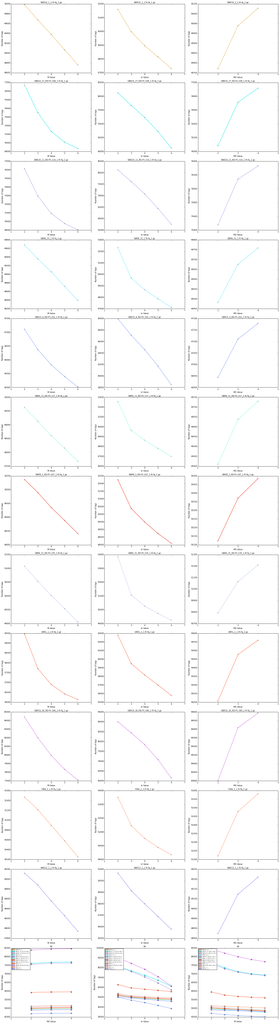

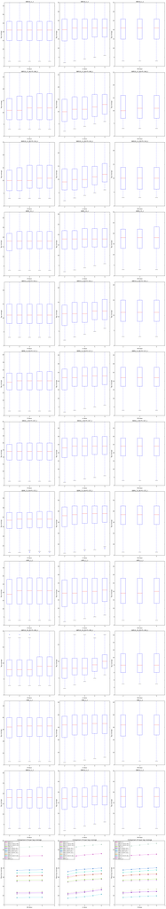

```python
Incremental_U_outputs = IncU.IncreMental_U(Setup_dict)
```

### Things to add / change in this step:

```
1. Switch for verbosity
2. Switch to show individual graphs (or just save to file and don't show?)
3. Fix legends in plots so they don't obscure the data
4. Fix order of last plots
5. Fix plot subtitles
6. Fix error if missing last "/" of fastq path
7. Capture log files
8. Add the ability to control the default values of the non-test parameters - e.g. When testing the 'M' parameter, allow user to specify value for 'm' and 'MS'
```

### There is now an intermediate step before we can proceed to the Cstacks tests:

Cstacks requires Ustacks outputs as its inputs. Obviously which Ustacks outputs we use will affect the Cstacks results. This is perhaps not a really big deal as the inputs for Cstacks will always be the same for all Cstacks tests - so the patterns across the Cstacks parameter values should be roughly the same regardless of the Ustacks inputs used. However, it would be good to allow the user to control this if they want.

For running the pipeline module by module separately, it is easy, we include a function (which I think I already have) to run Ustacks a final time for whatever parameter values the user likes.

But if we want to add an automated wrapper for the whole Incremental pipeline, we need to deal with this another way.

I think we could design the pipeline to run in two ways:

```
1. Automatic - The user defines all test parameter values and all default values for each module (Ustacks, Cstacks and Populations) in a single parameter file. Then, at the end of each step the final run of that model is run using the default parameter values or a set of specified values specifically for the final run.
2. Modular - The user runs the pipeline one module at a time, and manually runs the final commands for each module using a function that we include.
```

Example of 1.

User fills out parameters for all modules at start, including defaults:

```
Ustacks
- M_test = [2,3,4,5,6]
- m_test = [2,4,6,8]
- MS_test = None

- M_default = 2
- m_default = 4
- MS_default = 2

- M_final = 2
- m_final = 6
- MS_final = 2

Cstacks
- n_test = [2,3,4,5,6]

- n_default = 2

Populations
- p_test = [4,6,8,10]
- r_test = [0.7, 0.75, 0.8, 0.85, 0.9, 1]

- p_default = 4
- r_test = 0.75
```

So here, the Automatic pipeline will first run Incremental_U. For ecah of the test parameters (in this example we are not testing MS). So for Ustacks will by run for the following parameter values:

-M = 2 (test) -m = 4 (default) -MS = 2 (default)

-M = 3 (test) -m = 4 (default) -MS = 2 (default)

-M = 4 (test) -m = 4 (default) -MS = 2 (default)

-M = 5 (test) -m = 4 (default) -MS = 2 (default)

-M = 6 (test) -m = 4 (default) -MS = 2 (default)

-M = 2 (default) -m = 2 (test) -MS = 2 (default)

-M = 2 (default) -m = 4 (test) -MS = 2 (default)

etc . . . . you get the idea.

At the end of these tests, a final Ustacks run will be performed (or we can use outputs already generated if that combination happened to be included in the test parameters) usng these parameters:

-M = 2 (final) -m = 6 (final) -MS = 2 (final)

These Final Ustacks outputs will then be used for the Cstacks tests.

To run the pipeline in a modular way continue as below . . .

### 2. Cstacks tests - using Incremental _C

```python
%%bash

cp /home/djeffrie/Data/Incremental/Incremental_U/*/M_tests/M_2/*tsv.gz /home/djeffrie/Data/Incremental/Incremental_C/
```

One slightly annoying thing about the Incremental_C module (as it is now) is that it needs the 'Sample IDs' used in Stacks. You then give Incremental_C the IDs of the samples that you want to include in the test. **NOTE that the Cstacks step is by far the longest - its not easily parrallelisable so it is best to choose a few individuals at a time for these tests.

So here's a function (in the Incremental_C module) for finding the IDs. At some point I think we could incorporate this into the pipeline so the user just gives sample names, not IDs.

```python
## INPUT INCREMENTAL_C PARAMETERS HERE -----------------------------------------

## Get IDs for the test samples

Parameter_dict = {}
Parameter_dict["Get_IDs"] = True
Parameter_dict["Ustacks_outs_dir"] = "/home/djeffrie/Data/Incremental/Incremental_C/"

IncC.Incremental_C(Parameter_dict)
```

```
 ## Sample IDs:

FIN4_1_1, ID = 11
GBR10_27_RD-P1-168_1, ID = 2
GBR10_30_RD-P1-180_1, ID = 10
GBR15_4_RD-P1-102_1, ID = 5
GBR6_11_RD-P1-117_1, ID = 6
GBR6_31_RD-P1-135_1, ID = 8
GBR8_33_1, ID = 4
SWE10_1_1, ID = 1
SWE12_1_1, ID = 12
SWE20_11_RD-P1-110_1, ID = 3
SWE8_2_RD-P1-167_1, ID = 7
UKR1_1_1, ID = 9
```

### Using 2 test samples only

```python
## INPUT INCREMENTAL_C PARAMETERS HERE -----------------------------------------

Parameter_dict = {}
Parameter_dict["Get_IDs"] = False  ## Note that this is now false
Parameter_dict["batch_ID"] = 1
Parameter_dict["n_vals"] = [1,2,3,4]
Parameter_dict["threads"] = 7
Parameter_dict["Ustacks_outs_dir"] = "/home/djeffrie/Data/Incremental/Incremental_C/"
Parameter_dict["sample_ids"] = [4,10]   ## add specific sample ID's of samples you want to look at, if this is not all samples in the directory given above. Leave as empty list if not.
Parameter_dict["run_cline_switch"] = 1     ## to switch on (1) to run stacks cline or off (0) to run pipeline on existing outputs
```

```
### ----- Making and running command lines ----- ###

n value = 1
cstacks -b 1 -n 1 -s /home/djeffrie/Data/Incremental/Incremental_C//GBR8_33_1.fil -s /home/djeffrie/Data/Incremental/Incremental_C//GBR10_30_RD-P1-180_1.fil 7 -o /home/djeffrie/Data/Incremental/Incremental_C//n_1
Running Command line

n value = 2
cstacks -b 1 -n 2 -s /home/djeffrie/Data/Incremental/Incremental_C//GBR8_33_1.fil -s /home/djeffrie/Data/Incremental/Incremental_C//GBR10_30_RD-P1-180_1.fil 7 -o /home/djeffrie/Data/Incremental/Incremental_C//n_2
Running Command line

n value = 3
cstacks -b 1 -n 3 -s /home/djeffrie/Data/Incremental/Incremental_C//GBR8_33_1.fil -s /home/djeffrie/Data/Incremental/Incremental_C//GBR10_30_RD-P1-180_1.fil 7 -o /home/djeffrie/Data/Incremental/Incremental_C//n_3
Running Command line

n value = 4
cstacks -b 1 -n 4 -s /home/djeffrie/Data/Incremental/Incremental_C//GBR8_33_1.fil -s /home/djeffrie/Data/Incremental/Incremental_C//GBR10_30_RD-P1-180_1.fil 7 -o /home/djeffrie/Data/Incremental/Incremental_C//n_4
Running Command line


#### ---- Plotting the tag sharing patterns between individuals ---- ####

Number of samples specified: 2
```

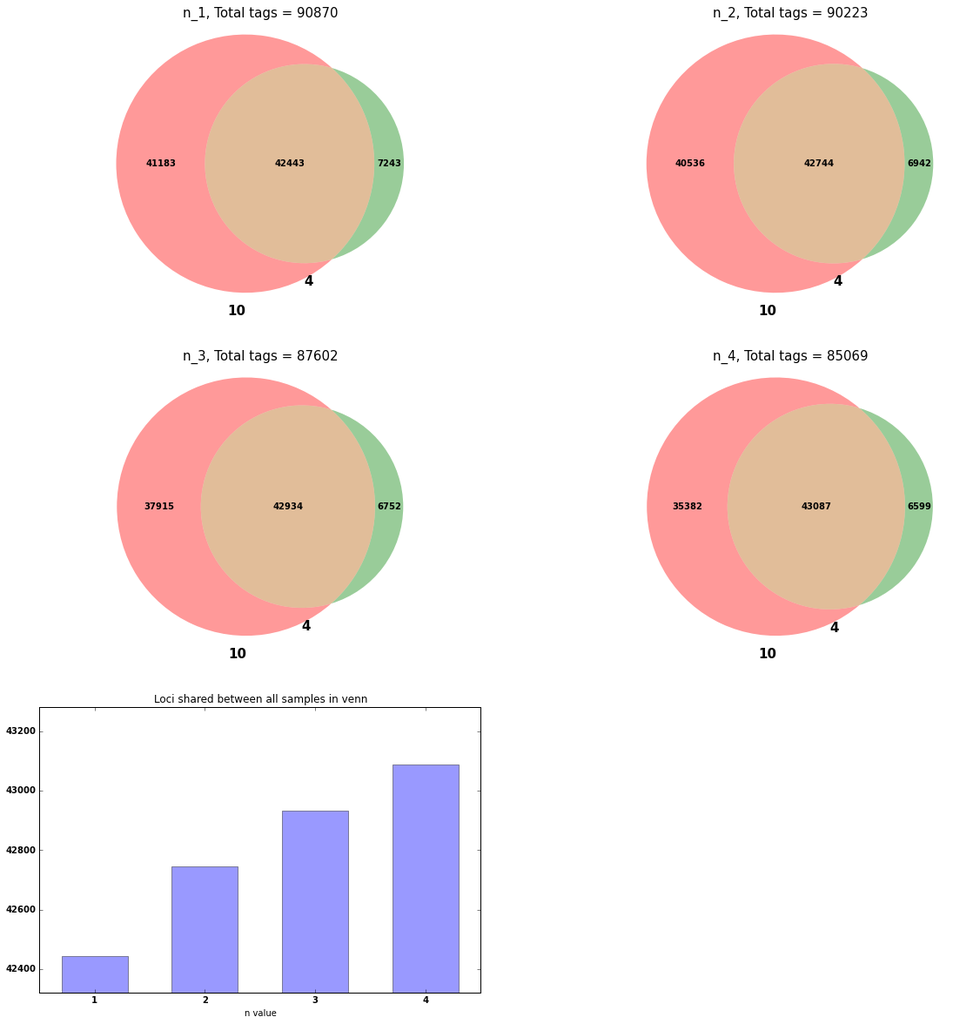

```python
IncC.Incremental_C(Parameter_dict)
```

### Using 3 test samples

```python
## INPUT INCREMENTAL_C PARAMETERS HERE -----------------------------------------

Parameter_dict = {}
Parameter_dict["Get_IDs"] = False
Parameter_dict["batch_ID"] = 1
Parameter_dict["n_vals"] = [1,2,3,4]
Parameter_dict["threads"] = 7
Parameter_dict["Ustacks_outs_dir"] = "/home/djeffrie/Data/Incremental/Incremental_C/"
Parameter_dict["sample_ids"] = [2,7,9]   ## add specific sample ID's of samples you want to look at, if this is not all samples in the directory given above. Leave as empty list if not.
Parameter_dict["run_cline_switch"] = 0     ## to switch on (1) to run stacks cline or off (0) to run pipeline on existing outputs
```

```
### ----- Making and running command lines ----- ###

n value = 1
cstacks -b 1 -n 1 -s /home/djeffrie/Data/Incremental/Incremental_C//UKR1_1_1.fil -s /home/djeffrie/Data/Incremental/Incremental_C//GBR10_27_RD-P1-168_1.fil -s /home/djeffrie/Data/Incremental/Incremental_C//SWE8_2_RD-P1-167_1.fil 7 -o /home/djeffrie/Data/Incremental/Incremental_C//n_1

n value = 2
cstacks -b 1 -n 2 -s /home/djeffrie/Data/Incremental/Incremental_C//UKR1_1_1.fil -s /home/djeffrie/Data/Incremental/Incremental_C//GBR10_27_RD-P1-168_1.fil -s /home/djeffrie/Data/Incremental/Incremental_C//SWE8_2_RD-P1-167_1.fil 7 -o /home/djeffrie/Data/Incremental/Incremental_C//n_2

n value = 3
cstacks -b 1 -n 3 -s /home/djeffrie/Data/Incremental/Incremental_C//UKR1_1_1.fil -s /home/djeffrie/Data/Incremental/Incremental_C//GBR10_27_RD-P1-168_1.fil -s /home/djeffrie/Data/Incremental/Incremental_C//SWE8_2_RD-P1-167_1.fil 7 -o /home/djeffrie/Data/Incremental/Incremental_C//n_3

n value = 4
cstacks -b 1 -n 4 -s /home/djeffrie/Data/Incremental/Incremental_C//UKR1_1_1.fil -s /home/djeffrie/Data/Incremental/Incremental_C//GBR10_27_RD-P1-168_1.fil -s /home/djeffrie/Data/Incremental/Incremental_C//SWE8_2_RD-P1-167_1.fil 7 -o /home/djeffrie/Data/Incremental/Incremental_C//n_4


#### ---- Plotting the tag sharing patterns between individuals ---- ####

Number of samples specified: 3
```

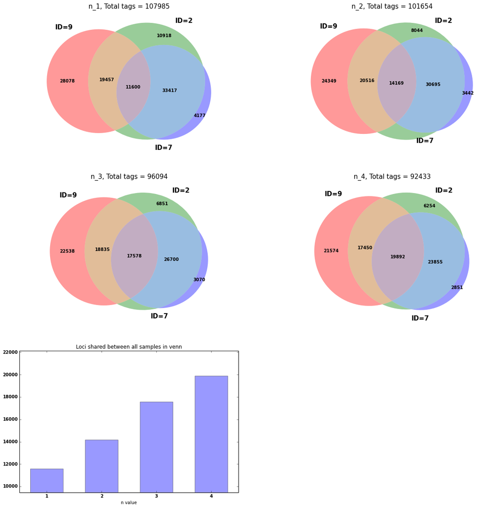

```python
IncC.Incremental_C(Parameter_dict)
```

### Using 4 test samples

```python
## INPUT INCREMENTAL_C PARAMETERS HERE -----------------------------------------

Parameter_dict = {}
Parameter_dict["Get_IDs"] = False
Parameter_dict["batch_ID"] = 1
Parameter_dict["n_vals"] = [1,2,3,4]
Parameter_dict["threads"] = 7
Parameter_dict["Ustacks_outs_dir"] = "/home/djeffrie/Data/Incremental/Incremental_C/"
Parameter_dict["sample_ids"] = [1,3,8,11]   ## add specific sample ID's of samples you want to look at, if this is not all samples in the directory given above. Leave as empty list if not.
Parameter_dict["run_cline_switch"] = 1     ## to switch on (1) to run stacks cline or off (0) to run pipeline on existing outputs
```

```
### ----- Making and running command lines ----- ###

n value = 1
cstacks -b 1 -n 1 -s /home/djeffrie/Data/Incremental/Incremental_C//SWE20_11_RD-P1-110_1.fil -s /home/djeffrie/Data/Incremental/Incremental_C//GBR6_31_RD-P1-135_1.fil -s /home/djeffrie/Data/Incremental/Incremental_C//SWE10_1_1.fil -s /home/djeffrie/Data/Incremental/Incremental_C//FIN4_1_1.fil 7 -o /…
Running Command line

n value = 2
cstacks -b 1 -n 2 -s /home/djeffrie/Data/Incremental/Incremental_C//SWE20_11_RD-P1-110_1.fil -s /home/djeffrie/Data/Incremental/Incremental_C//GBR6_31_RD-P1-135_1.fil -s /home/djeffrie/Data/Incremental/Incremental_C//SWE10_1_1.fil -s /home/djeffrie/Data/Incremental/Incremental_C//FIN4_1_1.fil 7 -o /…
Running Command line

n value = 3
cstacks -b 1 -n 3 -s /home/djeffrie/Data/Incremental/Incremental_C//SWE20_11_RD-P1-110_1.fil -s /home/djeffrie/Data/Incremental/Incremental_C//GBR6_31_RD-P1-135_1.fil -s /home/djeffrie/Data/Incremental/Incremental_C//SWE10_1_1.fil -s /home/djeffrie/Data/Incremental/Incremental_C//FIN4_1_1.fil 7 -o /…
Running Command line

n value = 4
cstacks -b 1 -n 4 -s /home/djeffrie/Data/Incremental/Incremental_C//SWE20_11_RD-P1-110_1.fil -s /home/djeffrie/Data/Incremental/Incremental_C//GBR6_31_RD-P1-135_1.fil -s /home/djeffrie/Data/Incremental/Incremental_C//SWE10_1_1.fil -s /home/djeffrie/Data/Incremental/Incremental_C//FIN4_1_1.fil 7 -o /…
Running Command line


#### ---- Plotting the tag sharing patterns between individuals ---- ####

Number of samples specified: 4

N tags in catalog n_1 = 84478, Number of loci shared by all = 42817
N tags in catalog n_2 = 83037, Number of loci shared by all = 43198
N tags in catalog n_3 = 82379, Number of loci shared by all = 43320
N tags in catalog n_4 = 82009, Number of loci shared by all = 43370
```

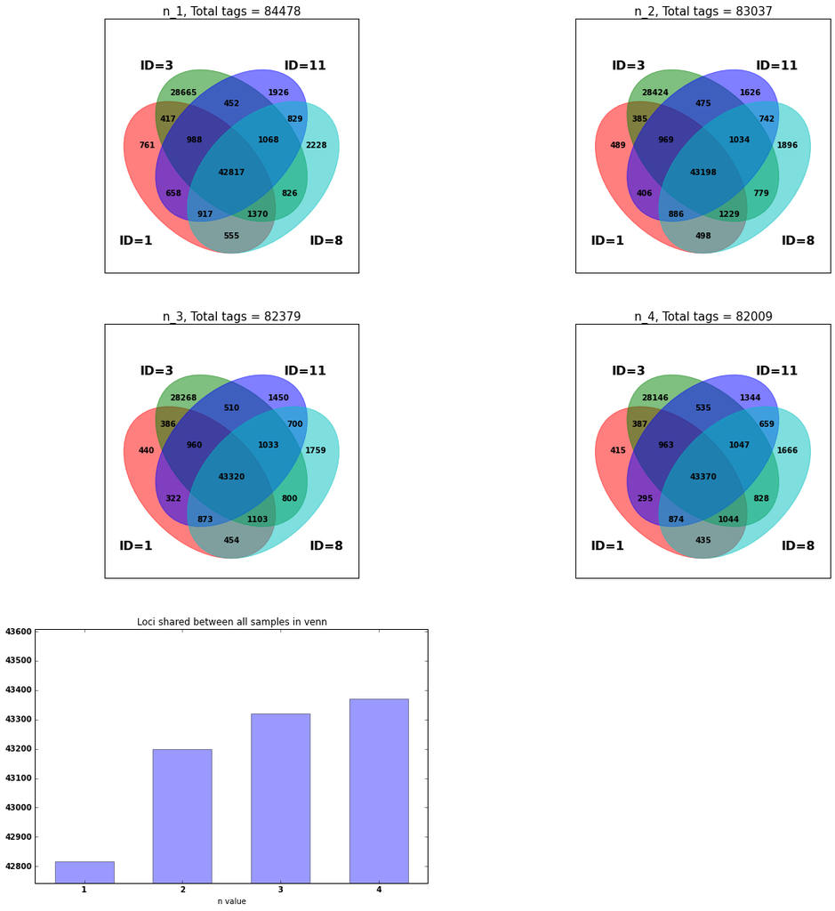

```python
IncC.Incremental_C(Parameter_dict)
```

## To do:

```
1. Important - at the moment Incremental_C puts outputs into the same directory as the sample files. However, if you run it multiple times from the same directory for example, using multiple combinations of samples, it will overide the outputs of previous runs. So we need to structure the output directories properly.
```

## We need to make another decision here. . . .

The Cstacks step is quite long - the more samples you use, the more loci are added to the catalog. The more loci in the catalog, the more time it takes to search further samples against that catalog. Thus computation time of this step can increase exponentially as more samples are added. Further more, it only possible to construct venn diagrams for 4 subsets of data - any higher and it becomes geometrically impossible to make a 2D plot of all overlaps. So I find that it is best at this stage to choose subsets of the dataset to test.

For example, as in the test data - the dataset may contain different species and hybrids. I would therefore run Incremental_C several times for different combinations of 3 or 4 samples at a time, comparing conspecifics in one run and comparing individuals from separate species, and potentially their hybrids in anoter run. This keeps computation time down, and informativeness up.

So in the automatic version of Incremental - I propose that the default is to randomly choose 3 sets of test samples, each with a different combination of individuals in the test data. We can however, allow the user to specify combinations of samples to test in this step in the parameter file.

Thoughts welcome here!

As an interesting test case, the 3 sample comparison above uses one pure C. carassius sample, one pure C. auratus sample and one F1 hybrid. You can see in the Venn diagrams how the hybrid contains more loci than either of the other two, and that many loci are shared just by the hybrid, and one of the parental species, but not the other. This is indicative of null alleles, where a Restriction site has been lost (or gained) in one of the parental species. The hybrid therefore inherits one allele containing a RAD site and one allele lacking a RAD site, meaning that it is essentially hemizygous at this locus. Although you can't see it in this step, these loci are likely to look almost entirely homozygous in the hybrid, and of course only half the coverage of the normal loci, as only one allele is being sequenced. This is a good example of how these tests can be informative for complex datasets.

I will probably try to include something like this in the paper (I am thinking somewhere like Mol.Ecol. resources would be good).

## Another intermediate step now.

The next step in the Stacks pipeline is to use the Sstacks module to search all individuals (using Ustacks inputs) against the catalog made with Cstacks.

There are no parameters here that are worth testing, so this step can just be run as usual in order to produce the outputs required for the final module, Populations.

For the automatic pipeline, before this step we will need to run the Cstacks step properly for all the samples before it can be used for the Sstacks step. So again I propose a similar system as in Incremental_U - the defualt parameters are used for the final Cstacks run, unless the user specifies final Cstacks parameters in the parameter file.

Once this has run, the Sstacks stage can be run automatically without any input from the user. And then we can move on to the Populations module of Stacks using Incremental_Pop.

## Populations tests - using Incremental_Pop

The Populations module of Stacks does a lot. It takes all of the outputs from the previous three Stacks modules, collects genotype and haplotype information for a set of specified samples and can output that information into a number of different formats. It also performs lots of population genetics analyses.

So far, Incremental deals with 3 parameters:

```
p: minimum number of populations a locus must be present in to process a locus.
r: minimum percentage of individuals in a population required to process a locus for that population.
m: specify a minimum stack depth required for individuals at a locus.
```

```python
## INPUT INCREMENTAL_C PARAMETERS HERE -----------------------------------------

Parameter_dict = {}
Parameter_dict["Get_IDs"] = False
Parameter_dict["batch_ID"] = 1
Parameter_dict["n_vals"] = [2]
Parameter_dict["threads"] = 7
Parameter_dict["Ustacks_outs_dir"] = "/home/djeffrie/Data/Incremental/Incremental_Pop/"
Parameter_dict["sample_ids"] = range(1,12,1)   ## doing all samples
Parameter_dict["run_cline_switch"] = 1     ## to switch on (1) to run stacks cline or off (0) to run pipeline on existing outputs
```

```python
IncC.Incremental_C(Parameter_dict)
```

```
### ----- Making and running command lines ----- ###

n value = 2
cstacks -b 1 -n 2 -s /home/djeffrie/Data/Incremental/Incremental_Pop//SWE20_11_RD-P1-110_1.fil -s /home/djeffrie/Data/Incremental/Incremental_Pop//GBR6_31_RD-P1-135_1.fil -s /home/djeffrie/Data/Incremental/Incremental_Pop//UKR1_1_1.fil -s /home/djeffrie/Data/Incremental/Incremental_Pop//GBR10_27_RD-…
Running Command line


#### ---- Plotting the tag sharing patterns between individuals ---- ####

Number of samples specified: 11
```

```
An exception has occurred, use %tb to see the full traceback.

SystemExit: Specified too many sample IDs, need at most 4
```

```
To exit: use 'exit', 'quit', or Ctrl-D.
```

Note - It failed - but Cstacks ran fine. Must be a bug in one of the plotting functions which looks for more than one sample. Probably the venn diagrams.

Now manually moved the catalog into the Incremental_Pop directory and maually ran Sstacks

```python
%%bash
mv /home/djeffrie/Data/Incremental/Incremental_Pop/n_2/batch_1.catalog* /home/djeffrie/Data/Incremental/Incremental_Pop/
rm -rf n_2*
```

```python
%%bash
sstacks -p 7 -b 1 -c /home/djeffrie/Data/Incremental/Incremental_Pop/batch_1 -s /home/djeffrie/Data/Incremental/Incremental_Pop/FIN4_1_1.fil -s /home/djeffrie/Data/Incremental/Incremental_Pop/GBR10_27_RD-P1-168_1.fil -s /home/djeffrie/Data/Incremental/Incremental_Pop/GBR10_30_RD-P1-180_1.fil -s /home/djeffrie/Data/Incremental/Incremental_Pop/GBR15_4_RD-P1-102_1.fil -s /home/djeffrie/Data/Incremental/Incremental_Pop/GBR6_11_RD-P1-117_1.fil -s /home/djeffrie/Data/Incremental/Incremental_Pop/GBR6_31_RD-P1-135_1.fil -s /home/djeffrie/Data/Incremental/Incremental_Pop/GBR8_33_1.fil -s /home/djeffrie/Data/Incremental/Incremental_Pop/SWE10_1_1.fil -s /home/djeffrie/Data/Incremental/Incremental_Pop/SWE12_1_1.fil -s /home/djeffrie/Data/Incremental/Incremental_Pop/SWE20_11_RD-P1-110_1.fil -s /home/djeffrie/Data/Incremental/Incremental_Pop/SWE8_2_RD-P1-167_1.fil -s /home/djeffrie/Data/Incremental/Incremental_Pop/UKR1_1_1.fil > /home/djeffrie/Data/Incremental/Incremental_Pop/Sstacks.log 2>&1 &
```

### And now running Incremental_Pop

Note, for Populations, you need to give a "popmap" which controls which samples are included in the analyses and which population each sample belongs to. The popmap I used for this analyses is in the outputs that I generated from this run through, you can find it here: /Incremental/

```python
## params for the Incremental populations analyses

Analysis_parameters1 = {}

## Test parameters
Analysis_parameters1["parameters"] = ["r","m"]
Analysis_parameters1["p_vals"] = [1,2,3]
Analysis_parameters1["p_default"] = 2 ## The value of p when other params are being tested. Set as 2 for males and females!
Analysis_parameters1["r_vals"] = [0.75, 0.85, 0.9, 0.95]
Analysis_parameters1["r_default"] = 0.75 ## The value of r when other params are being tested.
Analysis_parameters1["m_vals"] = [2,3,4,5,6]
Analysis_parameters1["m_default"] = 3 ## The value of m when other params are being tested.
Analysis_parameters1["Populations_test_dir_path"] = "/home/djeffrie/Data/Incremental/Incremental_Pop"
Analysis_parameters1["run_cline_switch"] = 1 ## run command line or not.

## Mandatory Populations options
Analysis_parameters1["b"] = 1 ## batch ID
Analysis_parameters1["P"] = "/home/djeffrie/Data/Incremental/Incremental_Pop/"## Path to stacks outputs
Analysis_parameters1["M"] = "/home/djeffrie/Data/Incremental/Incremental_Pop/popmap.txt" ## All samples

## Outputs parameters
Analysis_parameters1["vcf"] = True
Analysis_parameters1["vcf_haplotypes"] = True

## Optional parameters
Analysis_parameters1["t"] = 7 ## number of threads
Analysis_parameters1["min_maf"] = 0.05 ## number of threads

#Analysis_parameters1["B"] = None ## Locus blacklist
Analysis_parameters1["write_single_snp"] = True ## switch to write first snp of locus or not.
Analysis_parameters1["fstats"] = False
```

```
## Running command lines ##
populations -b 1 -P /home/djeffrie/Data/Incremental/Incremental_Pop/ -M /home/djeffrie/Data/Incremental/Incremental_Pop/popmap.txt -t 7 -r 0.75 -p 2 -m 3 --min_maf 0.05 --write_single_snp --vcf --vcf_haplotypes    ## FINISHED
Files moved to /home/djeffrie/Data/Incremental/Incremental_Pop/r_tests/r_075
## Running command lines ##
populations -b 1 -P /home/djeffrie/Data/Incremental/Incremental_Pop/ -M /home/djeffrie/Data/Incremental/Incremental_Pop/popmap.txt -t 7 -r 0.85 -p 2 -m 3 --min_maf 0.05 --write_single_snp --vcf --vcf_haplotypes    ## FINISHED
Files moved to /home/djeffrie/Data/Incremental/Incremental_Pop/r_tests/r_085
## Running command lines ##
populations -b 1 -P /home/djeffrie/Data/Incremental/Incremental_Pop/ -M /home/djeffrie/Data/Incremental/Incremental_Pop/popmap.txt -t 7 -r 0.9 -p 2 -m 3 --min_maf 0.05 --write_single_snp --vcf --vcf_haplotypes    ## FINISHED
Files moved to /home/djeffrie/Data/Incremental/Incremental_Pop/r_tests/r_09
## Running command lines ##
populations -b 1 -P /home/djeffrie/Data/Incremental/Incremental_Pop/ -M /home/djeffrie/Data/Incremental/Incremental_Pop/popmap.txt -t 7 -r 0.95 -p 2 -m 3 --min_maf 0.05 --write_single_snp --vcf --vcf_haplotypes    ## FINISHED
Files moved to /home/djeffrie/Data/Incremental/Incremental_Pop/r_tests/r_095
## Running command lines ##
populations -b 1 -P /home/djeffrie/Data/Incremental/Incremental_Pop/ -M /home/djeffrie/Data/Incremental/Incremental_Pop/popmap.txt -t 7 -r 0.75 -p 2 -m 2 --min_maf 0.05 --write_single_snp --vcf --vcf_haplotypes    ## FINISHED
Files moved to /home/djeffrie/Data/Incremental/Incremental_Pop/m_tests/m_2
## Running command lines ##
populations -b 1 -P /home/djeffrie/Data/Incremental/Incremental_Pop/ -M /home/djeffrie/Data/Incremental/Incremental_Pop/popmap.txt -t 7 -r 0.75 -p 2 -m 3 --min_maf 0.05 --write_single_snp --vcf --vcf_haplotypes    ## FINISHED
Files moved to /home/djeffrie/Data/Incremental/Incremental_Pop/m_tests/m_3
## Running command lines ##
populations -b 1 -P /home/djeffrie/Data/Incremental/Incremental_Pop/ -M /home/djeffrie/Data/Incremental/Incremental_Pop/popmap.txt -t 7 -r 0.75 -p 2 -m 4 --min_maf 0.05 --write_single_snp --vcf --vcf_haplotypes    ## FINISHED
Files moved to /home/djeffrie/Data/Incremental/Incremental_Pop/m_tests/m_4
## Running command lines ##
populations -b 1 -P /home/djeffrie/Data/Incremental/Incremental_Pop/ -M /home/djeffrie/Data/Incremental/Incremental_Pop/popmap.txt -t 7 -r 0.75 -p 2 -m 5 --min_maf 0.05 --write_single_snp --vcf --vcf_haplotypes    ## FINISHED
Files moved to /home/djeffrie/Data/Incremental/Incremental_Pop/m_tests/m_5
## Running command lines ##
populations -b 1 -P /home/djeffrie/Data/Incremental/Incremental_Pop/ -M /home/djeffrie/Data/Incremental/Incremental_Pop/popmap.txt -t 7 -r 0.75 -p 2 -m 6 --min_maf 0.05 --write_single_snp --vcf --vcf_haplotypes    ## FINISHED
Files moved to /home/djeffrie/Data/Incremental/Incremental_Pop/m_tests/m_6
##### Getting and plotting the data ######
/home/djeffrie/Data/Incremental/Incremental_Pop/r_tests/r_075/batch_1.vcf.altered
/home/djeffrie/Data/Incremental/Incremental_Pop/r_tests/r_075/batch_1.vcf.altered
/home/djeffrie/Data/Incremental/Incremental_Pop/r_tests/r_075/batch_1.vcf.altered
/home/djeffrie/Data/Incremental/Incremental_Pop/r_tests/r_075/batch_1.vcf.altered
/home/djeffrie/Data/Incremental/Incremental_Pop/r_tests/r_085/batch_1.vcf.altered
/home/djeffrie/Data/Incremental/Incremental_Pop/r_tests/r_085/batch_1.vcf.altered
/home/djeffrie/Data/Incremental/Incremental_Pop/r_tests/r_085/batch_1.vcf.altered
/home/djeffrie/Data/Incremental/Incremental_Pop/r_tests/r_085/batch_1.vcf.altered
/home/djeffrie/Data/Incremental/Incremental_Pop/r_tests/r_09/batch_1.vcf.altered
/home/djeffrie/Data/Incremental/Incremental_Pop/r_tests/r_09/batch_1.vcf.altered
/home/djeffrie/Data/Incremental/Incremental_Pop/r_tests/r_09/batch_1.vcf.altered
/home/djeffrie/Data/Incremental/Incremental_Pop/r_tests/r_09/batch_1.vcf.altered
```

[output cut: 17 more lines]

```
/home/djeffrie/Data/Incremental/Incremental_Pop/m_tests/m_3/batch_1.vcf.altered
/home/djeffrie/Data/Incremental/Incremental_Pop/m_tests/m_3/batch_1.vcf.altered
/home/djeffrie/Data/Incremental/Incremental_Pop/m_tests/m_3/batch_1.vcf.altered
/home/djeffrie/Data/Incremental/Incremental_Pop/m_tests/m_4/batch_1.vcf.altered
/home/djeffrie/Data/Incremental/Incremental_Pop/m_tests/m_4/batch_1.vcf.altered
/home/djeffrie/Data/Incremental/Incremental_Pop/m_tests/m_4/batch_1.vcf.altered
/home/djeffrie/Data/Incremental/Incremental_Pop/m_tests/m_4/batch_1.vcf.altered
/home/djeffrie/Data/Incremental/Incremental_Pop/m_tests/m_5/batch_1.vcf.altered
/home/djeffrie/Data/Incremental/Incremental_Pop/m_tests/m_5/batch_1.vcf.altered
/home/djeffrie/Data/Incremental/Incremental_Pop/m_tests/m_5/batch_1.vcf.altered
/home/djeffrie/Data/Incremental/Incremental_Pop/m_tests/m_5/batch_1.vcf.altered
/home/djeffrie/Data/Incremental/Incremental_Pop/m_tests/m_6/batch_1.vcf.altered
/home/djeffrie/Data/Incremental/Incremental_Pop/m_tests/m_6/batch_1.vcf.altered
/home/djeffrie/Data/Incremental/Incremental_Pop/m_tests/m_6/batch_1.vcf.altered
/home/djeffrie/Data/Incremental/Incremental_Pop/m_tests/m_6/batch_1.vcf.altered
```

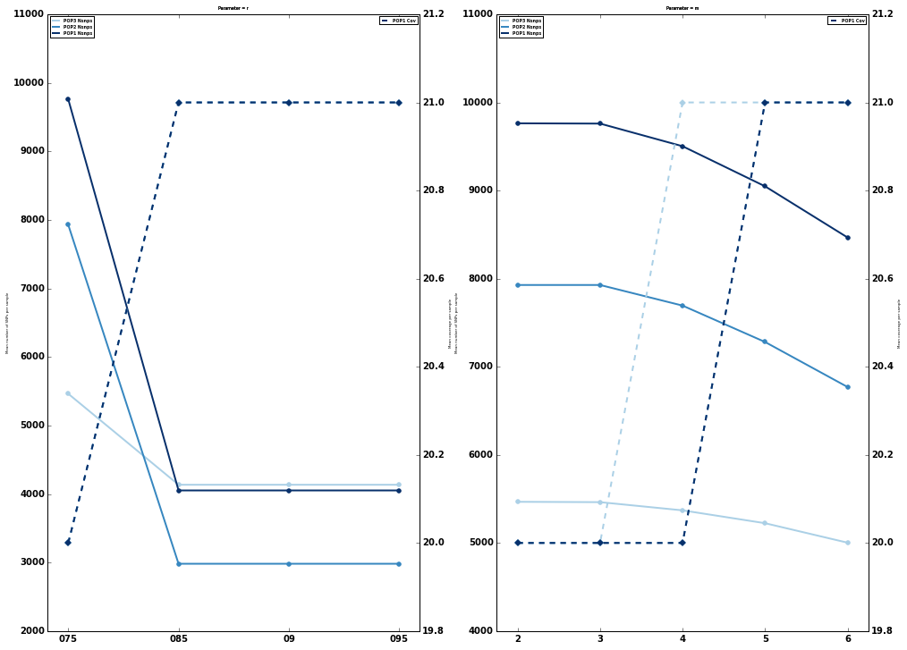

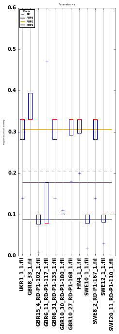

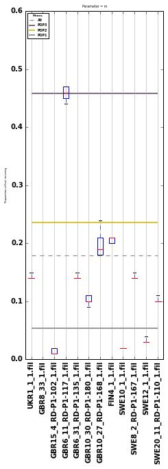

```python
Sample_data, Locus_data, group_info = IncPop.Incremental_Pop(Analysis_parameters1)
```

Let me know what you think about the graphs outputted by Incremental_Pop. The box plots look weird here, because so few samples were used. I would normally run IncPop on many more samples, as this step is quite short computationally. As I mentioned, I would like to add another plot which includes heterozygosity vs coverage. And maybe some more based on the Fstats if useful.

Again, we can include IncPop in the automated pipeline, but I really prefer to run it separately, as its very difficult to get an idea of the effect of the data filters (p, r) on just a small subset of the data. So in the automated pipeline, perhaps we can have a switch string for example. The pipeline might be run like this

Incremental(parameter_dict, "110") ## for within python

or

python Incremental.py --parameters /path/to/param/file.txt --switch 110 ## for command line.

where the switch string "110" would mean run Incremental_U and Incremental_C but not Incremental_Pop and the string "100" would run just Incremental_U.

## To do

```
1. Save figures to files
2. Add heterozygosity vs cov plot
```